# forecast var

TanQingyue

2020/5/19

### 2.实际操作

### 2.1包载入与数据预处理

```r
#包载入
library(fGarch)
library(rugarch)#garch拟合与预测
library(TSA)#BIC准则确定arma阶数  eacf确定garch阶数
library(tseries)
library(zoo)#转换成时间序列类型
library(forecast)#auto.arima() arma阶数确定方法
library(psych)#数据描述统计分析
```

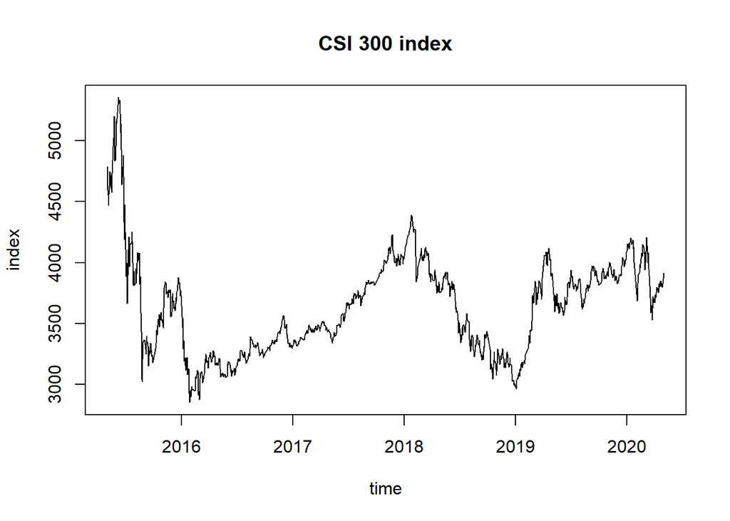

```r
library(ggplot2)#绘图
library(ccgarch)#JB统计量

#数据预处理
StockData<-read.csv("C://Users//Administrator//Desktop//project-lucky-girl-master//data//hushen300.csv",encoding='utf-8',header = T)  #header = Falese
time<-as.Date(StockData$'time',format="%Y/%m/%d")
closeprice<-StockData$'closeprice'
data<-zoo(closeprice,time)
#选中局部数据
selectdata=window(data, start = as.Date("2015-05-01"), end = as.Date("2020-05-01"))
plot(selectdata,xlab="time",ylab="index",main="CSI 300 index")
```

```r
rlog=log(selectdata)
rlogdiff=diff(log(selectdata))*100 #数据转换
rlogdifftime=index(rlogdiff)
rlogdiffdata=coredata(rlogdiff)
```

### 2.2正态性检验

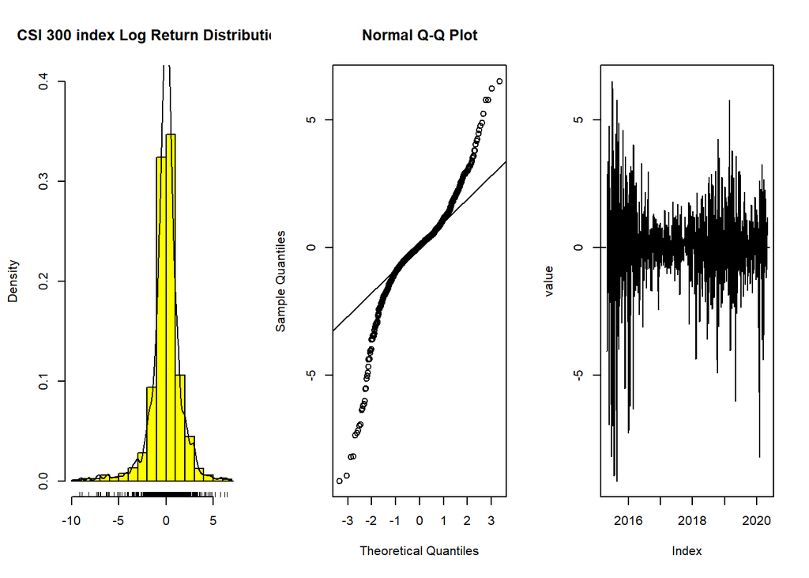

```r
par(mfrow=c(1,3),oma=c(0.2,0.2,0.2,0.2))
hist(rlogdiff,main="CSI 300 index Log Return Distribution",col="yellow",xlab="",ylim=c(0,0.4),probability=T)
lines(density(rlogdiff),lwd=1);rug(rlogdiff)#first graph
qqnorm(rlogdiff);qqline(rlogdiff)#second graph
plot(rlogdiff,ylab="value");abline(h=0,lty=2)#third graph
```

上图为数据分布函数，QQ图，对数收益率序列折现图。收益率分布图、QQ图可以看出金融时间序列确实表现出尖峰厚尾性，相对于标准正态分布，峰度更高，两段的尾部更厚，也就是极值更多。由收益率波动序列可以看出各国股票指数收益率序列在样本区间内均表现出一定的波动性和聚集性，其中2015-2016年、2020年初波动幅度尤为明显。

### 2.3平稳性检验

```r
#若 ADF  p<0.01  认为序列是均值回归的
adf.test(rlog,alt="stationary")#注意  这是未差分的数据
```

```
##
##  Augmented Dickey-Fuller Test
##
## data:  rlog
## Dickey-Fuller = -3.226, Lag order = 10, p-value = 0.08343
## alternative hypothesis: stationary
```

```r
adf.test(rlogdiffdata,alt="stationary")#这是差分后的数据
```

```
##
##  Augmented Dickey-Fuller Test
##
## data:  rlogdiffdata
## Dickey-Fuller = -11.054, Lag order = 10, p-value = 0.01
## alternative hypothesis: stationary
```

```r
#得先arima拟合模型，对残差进行LM检验
armamodel=auto.arima(rlogdiff)#自动基于AIC最小准则，寻找最佳拟合模型
armamodel
```

```
## Series: rlogdiff
## ARIMA(1,0,0) with zero mean
##
## Coefficients:
##           ar1
##       -0.0151
## s.e.   0.0348
##
## sigma^2 estimated as 2.418:  log likelihood=-2267.25
## AIC=4538.49   AICc=4538.5   BIC=4549.51
```

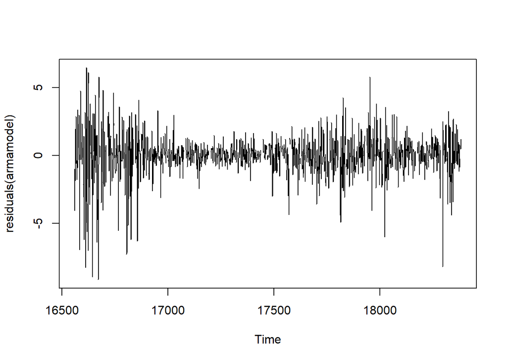

```r
plot(residuals(armamodel))
```

```r
par(mfrow=c(1,1))
lmresult=McLeod.Li.test(y=residuals(armamodel))#残差arch效应很显著
```

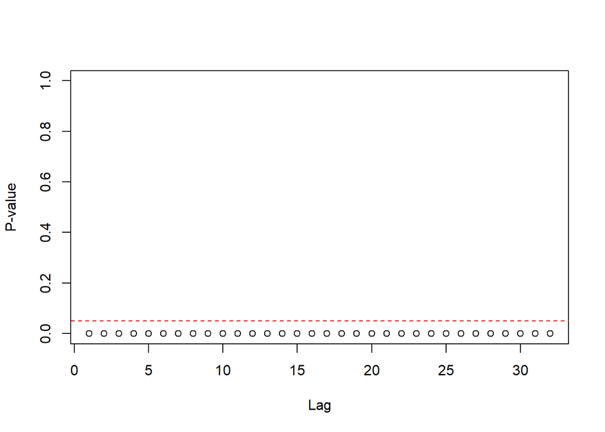

当p<0.01时认为序列平稳 由图可知，残差序列滞后30阶后，残差自回归函数的系数显著，序列仍然存在自相关。因此拒绝原假设，说明样本序列存在显著的ARCH效应。 综上，对数收益率序列具有波动聚集性，序列平稳，有显著ARCH效应。序列适合GARCH模型建模。

### 2.4模型拟合

分别使用SGARCH与EGARCH模型拟合序列。但由于是EGARCH能分析收益率序列的“杠杆效应”此处以EGARCH做演示。

```r
myspec=ugarchspec(
  variance.model = list(model = "eGARCH", garchOrder = c(1, 1)),
  mean.model = list(armaOrder = c(0,0), include.mean = TRUE),
  distribution.model = "std"
)

myfit=ugarchfit(myspec,data=rlogdiff,solver="gosolnp")
myfit
```

```
##
## *---------------------------------*
## *          GARCH Model Fit        *
## *---------------------------------*
##
## Conditional Variance Dynamics
## -----------------------------------
## GARCH Model  : eGARCH(1,1)
## Mean Model   : ARFIMA(0,0,0)
## Distribution : std
##
## Optimal Parameters
## ------------------------------------
##         Estimate  Std. Error   t value Pr(>|t|)
## mu      0.057175    0.024824   2.30321 0.021267
## omega   0.003425    0.004564   0.75048 0.452965
## alpha1 -0.048016    0.020557  -2.33576 0.019504
## beta1   0.986552    0.001771 557.05146 0.000000
## gamma1  0.169875    0.029654   5.72856 0.000000
## shape   4.205006    0.515719   8.15367 0.000000
##
## Robust Standard Errors:
##         Estimate  Std. Error    t value Pr(>|t|)
## mu      0.057175    0.025018    2.28538 0.022291
## omega   0.003425    0.004751    0.72088 0.470984
## alpha1 -0.048016    0.021506   -2.23269 0.025569
## beta1   0.986552    0.000535 1842.74204 0.000000
## gamma1  0.169875    0.031097    5.46274 0.000000
## shape   4.205006    0.520363    8.08090 0.000000
##
## LogLikelihood : -1915.07
##
## Information Criteria
## ------------------------------------
##
## Akaike       3.1519
## Bayes        3.1770
## Shibata      3.1518
## Hannan-Quinn 3.1613
##
```

[output cut: 43 more lines]

```
## Negative Sign Bias   1.476 0.1402
## Positive Sign Bias   1.276 0.2021
## Joint Effect         3.840 0.2793
##
##
## Adjusted Pearson Goodness-of-Fit Test:
## ------------------------------------
##   group statistic p-value(g-1)
## 1    20     11.27       0.9144
## 2    30     28.67       0.4823
## 3    40     37.34       0.5457
## 4    50     38.38       0.8628
##
##
## Elapsed time : 1.706937
```

### 2.5模型诊断

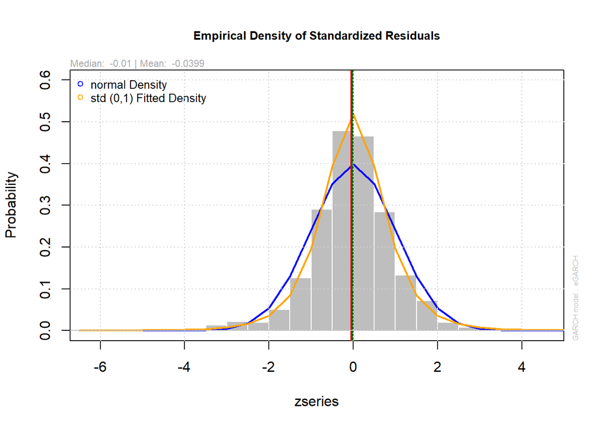

```r
#残差正态性检验
plot(myfit,which=8)
```

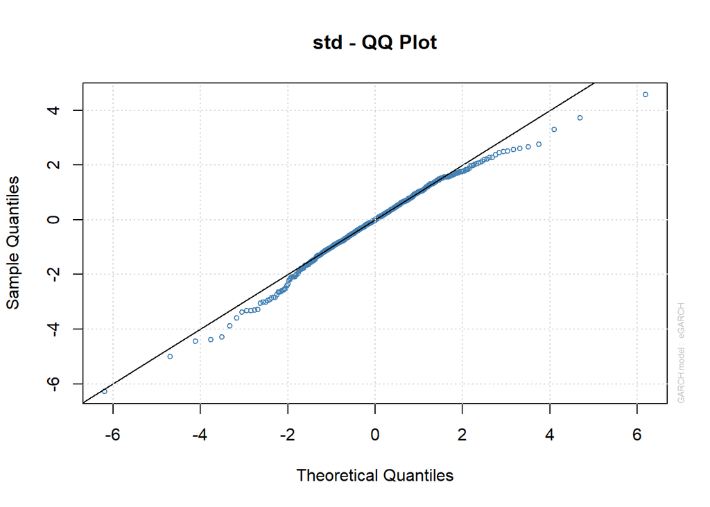

```r
plot(myfit,which=9)
```

```r
shapiro.test(coredata(residuals(myfit)))#值越大，越表示不是正态，P越小越非正态
```

```
##
##  Shapiro-Wilk normality test
##
## data:  coredata(residuals(myfit))
## W = 0.88922, p-value < 2.2e-16
```

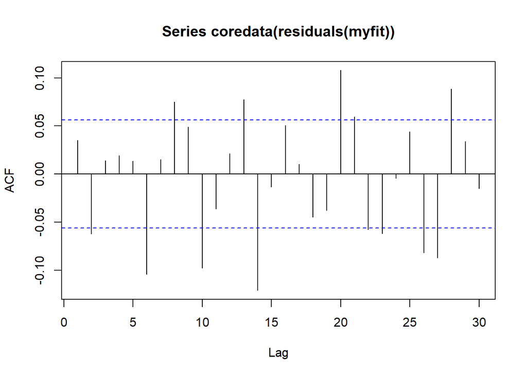

```r
#残差相关性检验
acf(coredata(residuals(myfit)))
```

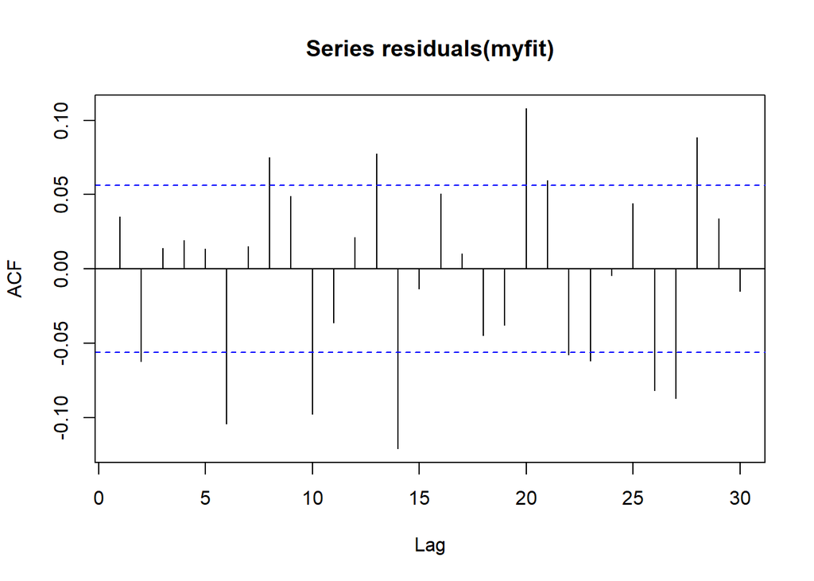

```r
acf(residuals(myfit))
```

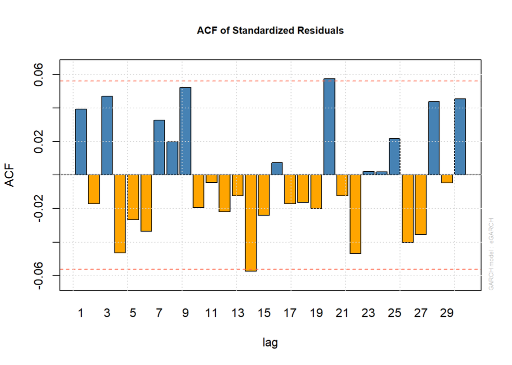

```r
plot(myfit,which=10)
```

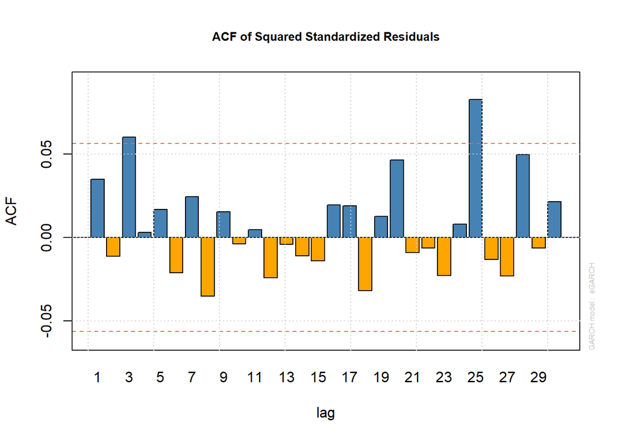

```r
plot(myfit,which=11)
```

```r
#系数是否显著
myfit #看P值是否够小
```

```
##
## *---------------------------------*
## *          GARCH Model Fit        *
## *---------------------------------*
##
## Conditional Variance Dynamics
## -----------------------------------
## GARCH Model  : eGARCH(1,1)
## Mean Model   : ARFIMA(0,0,0)
## Distribution : std
##
## Optimal Parameters
## ------------------------------------
##         Estimate  Std. Error   t value Pr(>|t|)
## mu      0.057175    0.024824   2.30321 0.021267
## omega   0.003425    0.004564   0.75048 0.452965
## alpha1 -0.048016    0.020557  -2.33576 0.019504
## beta1   0.986552    0.001771 557.05146 0.000000
## gamma1  0.169875    0.029654   5.72856 0.000000
## shape   4.205006    0.515719   8.15367 0.000000
##
## Robust Standard Errors:
##         Estimate  Std. Error    t value Pr(>|t|)
## mu      0.057175    0.025018    2.28538 0.022291
## omega   0.003425    0.004751    0.72088 0.470984
## alpha1 -0.048016    0.021506   -2.23269 0.025569
## beta1   0.986552    0.000535 1842.74204 0.000000
## gamma1  0.169875    0.031097    5.46274 0.000000
## shape   4.205006    0.520363    8.08090 0.000000
##
## LogLikelihood : -1915.07
##
## Information Criteria
## ------------------------------------
##
## Akaike       3.1519
## Bayes        3.1770
## Shibata      3.1518
## Hannan-Quinn 3.1613
##
```

[output cut: 43 more lines]

```
## Negative Sign Bias   1.476 0.1402
## Positive Sign Bias   1.276 0.2021
## Joint Effect         3.840 0.2793
##
##
## Adjusted Pearson Goodness-of-Fit Test:
## ------------------------------------
##   group statistic p-value(g-1)
## 1    20     11.27       0.9144
## 2    30     28.67       0.4823
## 3    40     37.34       0.5457
## 4    50     38.38       0.8628
##
##
## Elapsed time : 1.706937
```

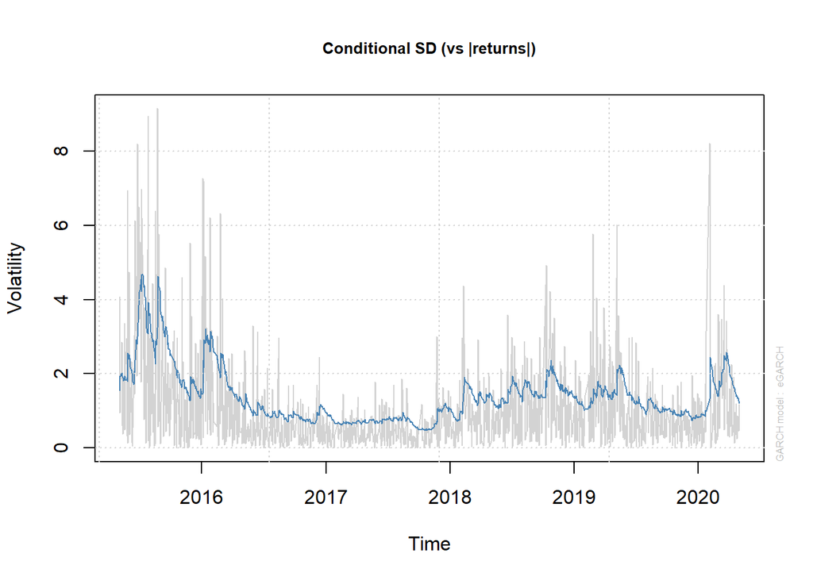

```r
#拟合效果  残差如何
plot(myfit,which=3)
```

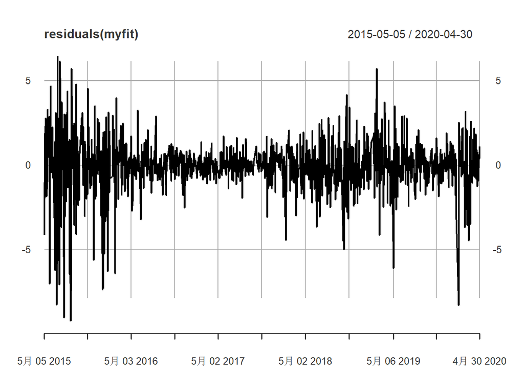

```r
plot(residuals(myfit)) #看残差
```

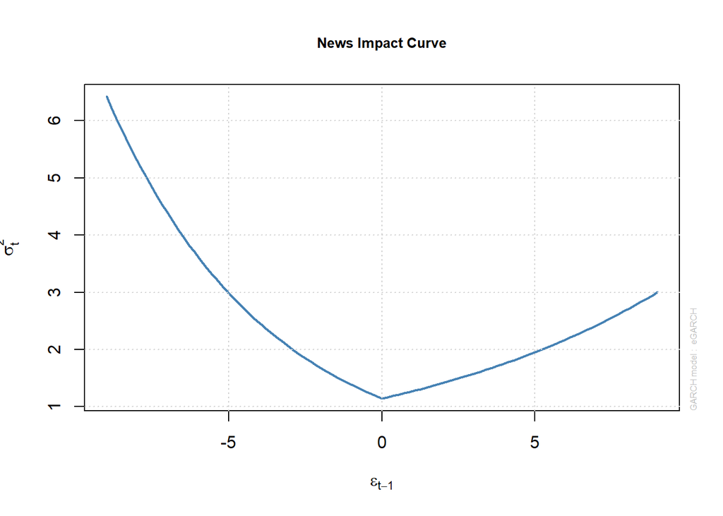

```r
plot(myfit,which=12)
```

### 2.6基于VAR曲线的收益风险预警

股票指数收益率计算公式为r_t=ln（e_(t))-lna(e_(t-1))，其中r_t为股票指数收益率，e_t和e_(t-1)分别为第t期和（t-1）期的股票指数收盘价 因此股票对数收益率有波动聚集性，这意味着大波动不是突然发生的，是由某些原因带来的冲击，而大波动发生之前也应该有相应信号出现，比如异常低的收益率。

```r
spec = ugarchspec(variance.model = list(model = "sGARCH"), distribution.model = "std")
cl = makePSOCKcluster(10)
#滚动预测
roll = ugarchroll(spec, rlogdiff, n.start =300,refit.every = 300,
                  refit.window = "moving", solver = "hybrid", calculate.VaR = TRUE,
                  VaR.alpha = c(0.01, 0.025, 0.05), cluster = cl,keep.coef = TRUE)

report(roll, type = "fpm")
```

```
##
## GARCH Roll Mean Forecast Performance Measures
## ---------------------------------------------
## Model        : sGARCH
## No.Refits    : 4
## No.Forecasts: 919
##
##      Stats
## MSE 1.3520
## MAE 0.8093
## DAC 0.4940
```

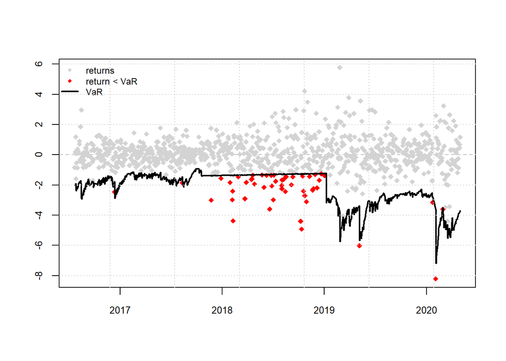

```r
plot(roll,which=4,VaR.alpha=0.01)
```

由上图可知在较大波动率之前确实有一些点落在Var曲线以下（标注为红点）。但在波动平稳期，模型预警正确率不高（如2017年10月到2019年1月）所以该模型在波动率非平稳期有一定参考价值。

以沪深300指数为例，在2020年初开始有个别点落在了var曲线以下这与新冠肺炎的出现时间相吻合。可见，现在沪深300指数的大跌在疫情出现之前是有留下一定信号的。